# FLASH-seq ONT

# Variables

| Sample ID | barcode10 |
| --- | --- |
| Output Directory | /home/vincent.hahaut/data_storage/ONT/130723_PAO51778_FSNanopore//barcode10_FLASHseqONT_output/ |
| Number of Input Reads | 3137022 |
| PCR Adapter (chimeric detection) | AAGCAGTGGTATCAACGCAGAGT |
| Barcode / Adapter / (UMI) detection windows (bp) | 200 |
| Chimeric Detection - Seq. identity (%) | 75 |
| Validate Chim. Reads | TRUE |
| Validate Chim. Reads - overlap read/segment | 0.8 |
| Barcode Detection Seq. | CGACGCTCTTCCGATCTNNNNNNNNNNNNNAAGCAGTGGTATCAACGCAGAGT |
| Barcode Identity (%) | 0.75 |
| Barcode Max. Levenstein Distance | 2 |
| Barcode Selected (#) | 384 |
| Read Trimming | TRUE |
| Demultiplexing - Min. Reads per chunk | 100 |

# Input FASTQ

- Read lengths (0-12Kb limits)
- Number of raw reads
- Read average-phred score

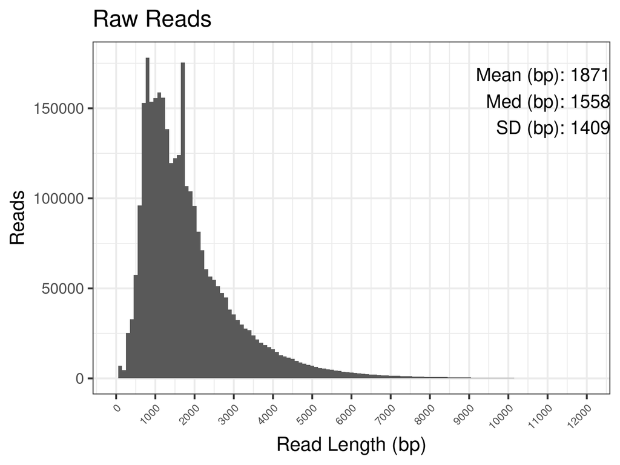

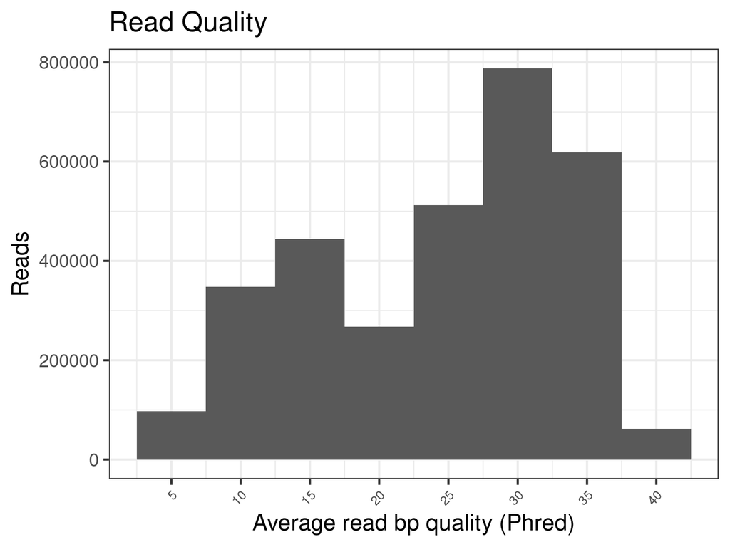

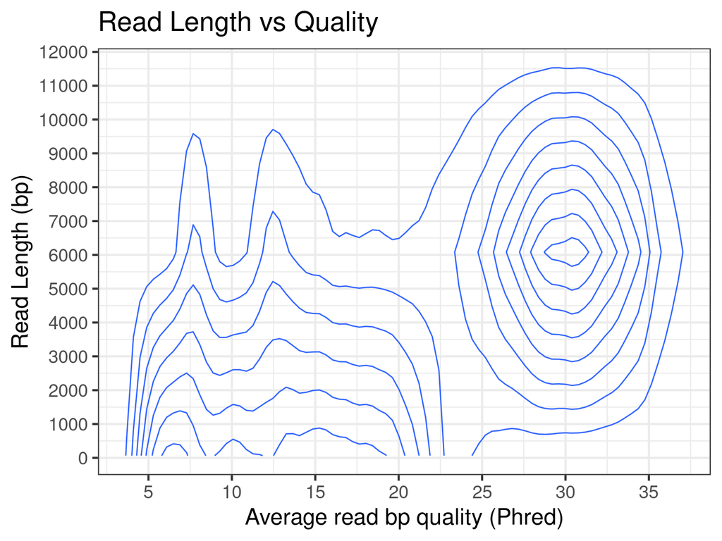

# Chimeric Reads Detection

## BLAST

Nanopore libraries are prepared by ligation. This method is prone to the formation of chimeric artefacts where two or more reads are combined. To detect and split these reads, BLASTn-Short is used, looking for the pcr adapter sequence: AAGCAGTGGTATCAACGCAGAGT.

| PCR Adapter detection (reads, #) | 1488675.000 |
| --- | --- |
| PCR Adapter detection (reads, %) | 47.455 |
| PCR Adapter detection + strand (reads, #) | 1322201.000 |
| PCR Adapter detection + strand, from raw reads (reads, %) | 42.148 |
| PCR Adapter detection - strand (reads, #) | 1263618.000 |
| PCR Adapter detection - strand, from raw reads (reads, %) | 40.281 |

BLAST is looking for sequences with an identity to the PCR adapter sequence > 0.75%. The longer the match the more likely it is an actual PCR adapter (length: 23).

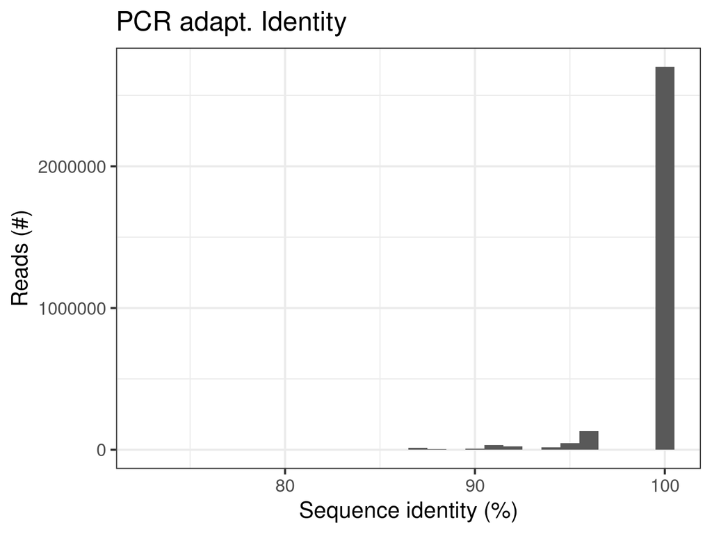

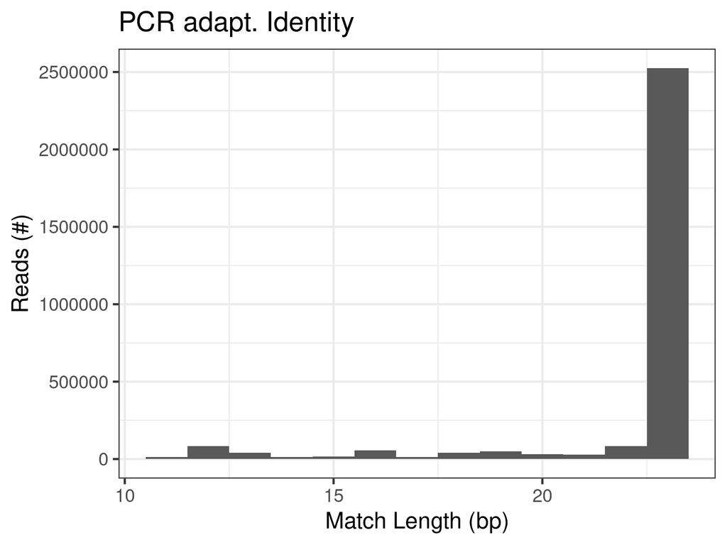

The PCR adapter sequences are expected to be at the read edges (5’ and 3’). Sequences located inside the read body can be associated to chimeric reads.

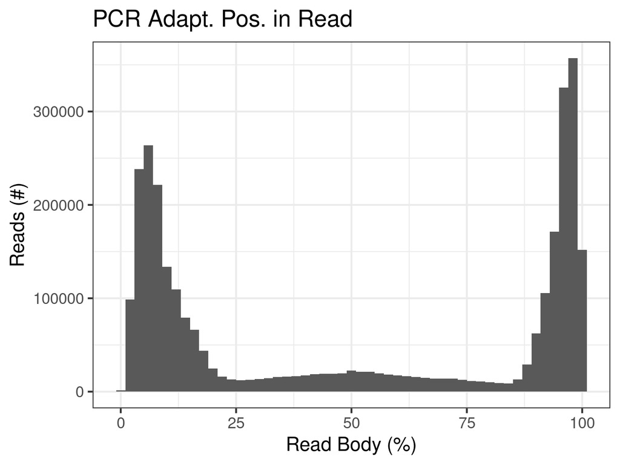

Ideal FLASH-seq ONT reads contain two PCR adapter sequences per read. One in ‘Forward’ and one in ‘Reverse’ orientation. Additional ones may be the reflect of chimeric artefacts.

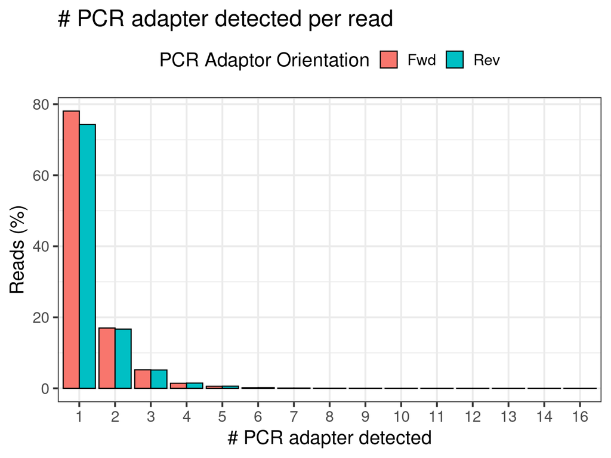

## Chimeric Segment

Chimeric reads are defined as having at least one PCR adapter in the read body (> 200 bp away of a read edge) and/or having >2 PCR adapters.

NB: Some reads may have a single internal adapter and be flagged as chimeric, despite showing a single segment. For this reason the mean number of ligated segments can theoretical be <2. These reads will follow the same path as regular chimeric segments. The splitting function will extract the appropriate segment from these reads. The mapping validation will verify if the split is appropriate or will flag them as problematic, later to be removed.

[output not shown]

Reads from FLASH-seq ONT libraries are flanked by the PCR adapter sequences. We define three types of reads:

- **==>…**: The read has one PCR adapter sequence in positive orientation.
- **…<==**: The read has one PCR adapter sequence at negative orientation.
- **==>…<==**: The read is flanked by two PCR adapter sequences in opposite orientations.

Chimeric reads follow the same logic but can harbor different combinations. For instance,

…<==|==>…<==|==>…

Based on the PCR adapter orientations the chimeric reads can be split into **segments**. The following graphic display the proportion of these segments in chimeric reads (= made of multiple sub-segments or a PCR adapter sequence in the read body) in green versus regular reads in orange (= made of one type of segment). The percentage is calculated based on the number of raw input reads.

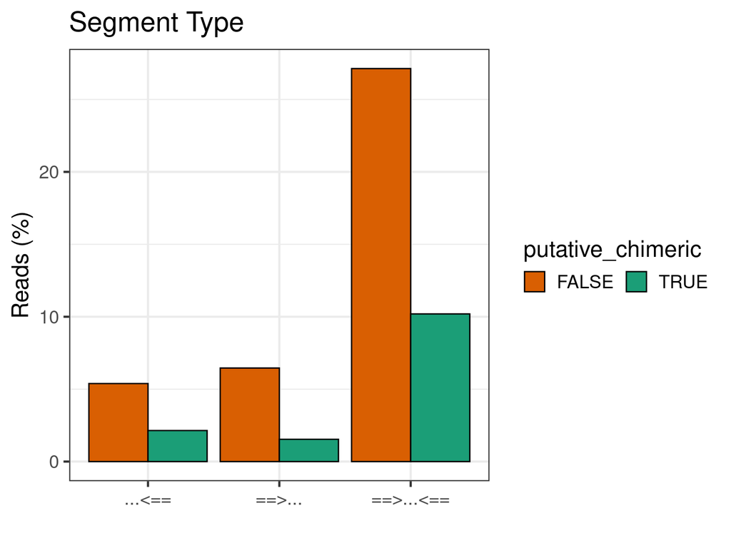

Read length distribution before splitting the chimeric reads (0-12kb).

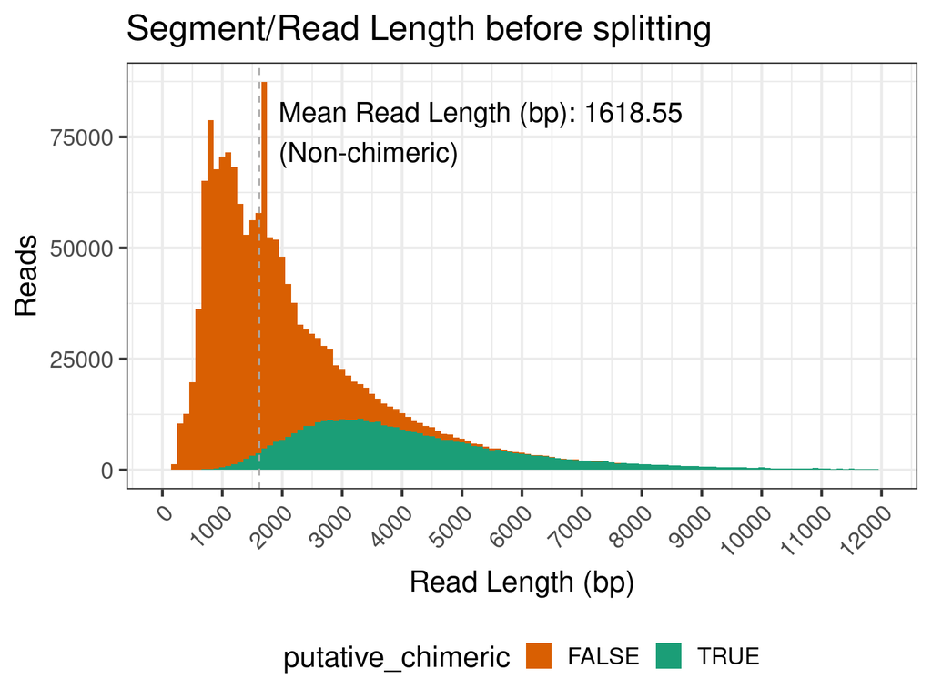

Read length distribution after splitting the chimeric reads into segments.

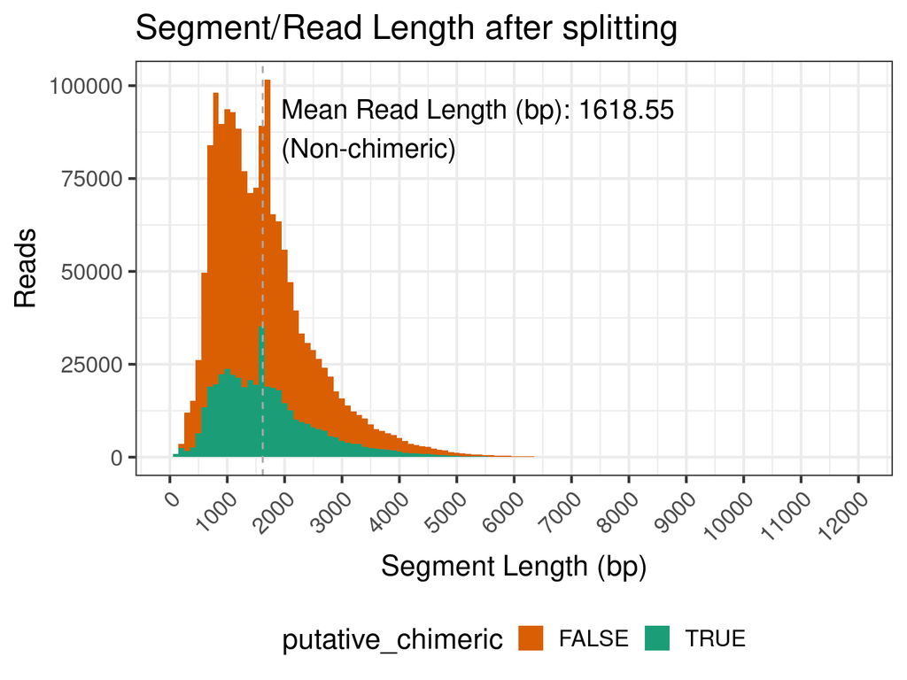

## Mapping Validation

### Banlist

Chimeric reads are split into segments. To validate the breakpoints, the chimeric segments/reads are mapped using minimap2.. The mapping of the chimeric reads (primary/supplementary) and segments (primary only) are compared. The overlap between the read/segment mappings is expected to be >80% or the breakpoints are considered as erroneous and the segment/read is flagged (=banlist), later to be discarded.

| Putative chimeric segments (post-split) | 435236.000 |
| --- | --- |
| Mapping rate (%) | 187.517 |
| Problematic Reads (banlist, #) | 26270.000 |
| Problematic Reads (banlist, % chim. segs.) | 6.036 |
| Problematic Reads (banlist, % total) | 0.837 |

Problematic reads - reasons:

- `In-silico chimeric` = In silico chimeric reads not correctly split by Dorado/guppy.
- `No match chim. read/segm. Mappings` = No match between the split segment primary alignment and the the read mapping (primary / suppl.).
- `Partial match chim. read/segm. Mappings` = Match between the split segment primary alignment and the the read mapping (primary / suppl.) is below 0.8.

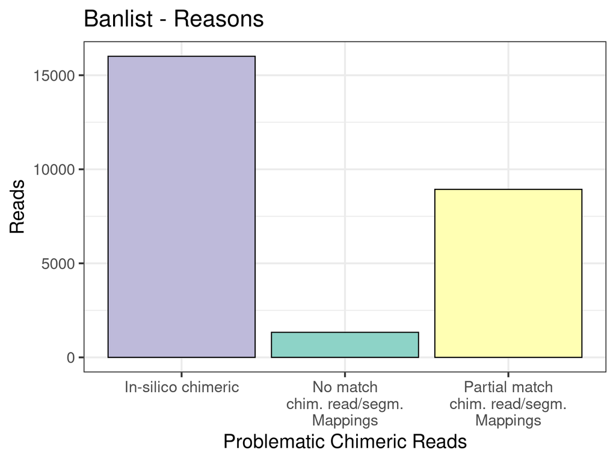

Overlap between the read and segments:

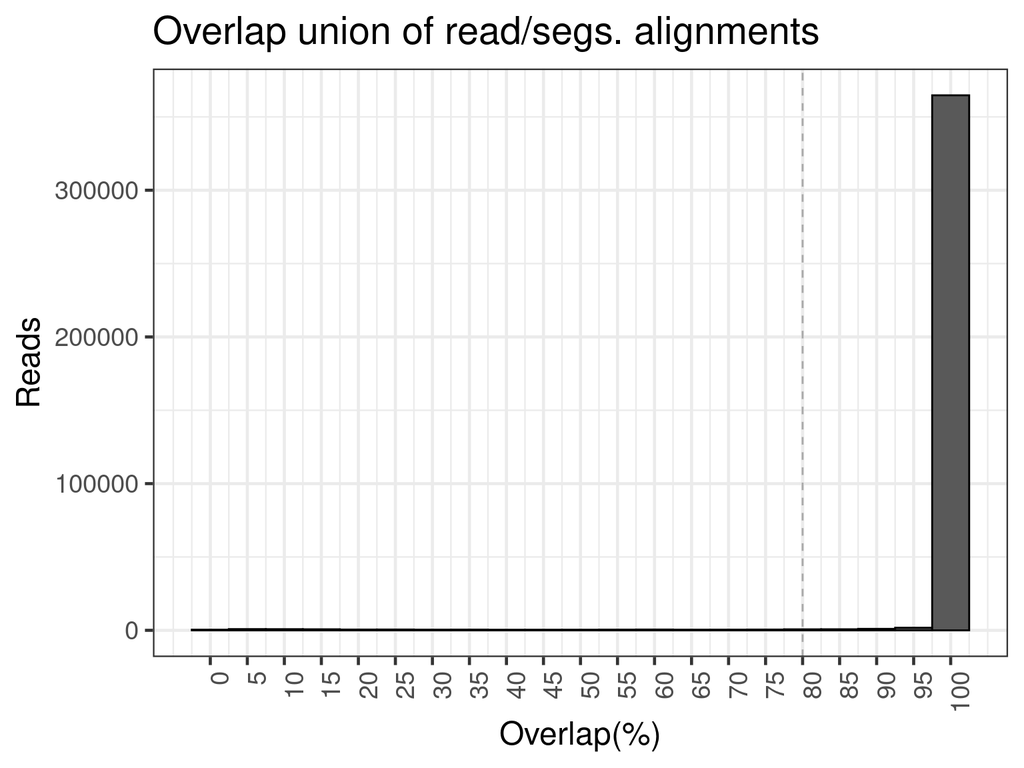

In silico-chimeric reads can occur when the second strand follows too quickly into the pore and is artificially attached to the first read. We have observed an increase of these events when the flowcell is overloaded (R10.4).

- https://f1000research.com/articles/6-631/v2
- https://github.com/nanoporetech/dorado

Dorado basecaller or duplex_tools can in theory remove these artifacts. However, in some cases they are left behind and represent an issue for this pipeline as they could be split into two distinct molecules, leading to over-counting. To exclude these events, the segment mappings (primary/supplementary) belonging to a single read are compared. If two segments originating from the same chimeric read are mapping at the same position (overlap >0%) in opposite orientations, they are considered as in-silico chimerics. The smallest alignment of the two is then flagged, later to be removed.

# Barcodes - VSEARCH

The barcode primer position is searched in the first/last 200 bp of the read using vsearch:

CGACGCTCTTCCGATCTNNNNNNNNNNNNNAAGCAGTGGTATCAACGCAGAGT

| Reads with at least one detected barcode (#) | 1626891.00 |
| --- | --- |
| Reads with at least one detected barcode (%) | 51.86 |
| Reads with at least one detected good barcode (#) | 1342796.00 |
| Reads with at least one detected good barcode (%) | 42.80 |

Only sequences displaying an identity >75% are retained:

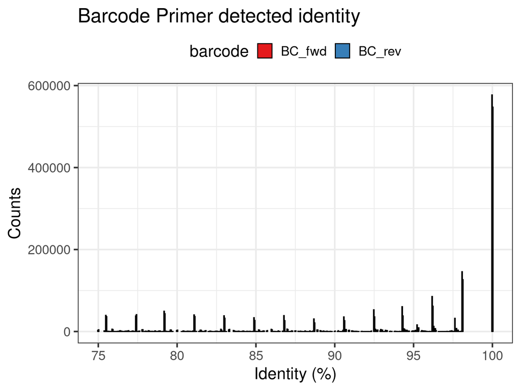

The identity values returned by vsearch do not account for the length. We expected an average length around 53.

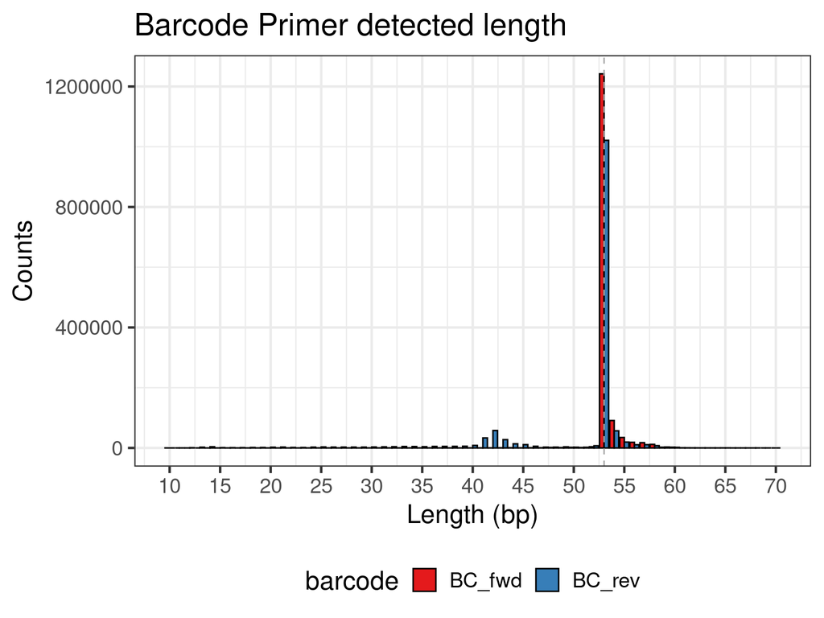

Barcode error rate.

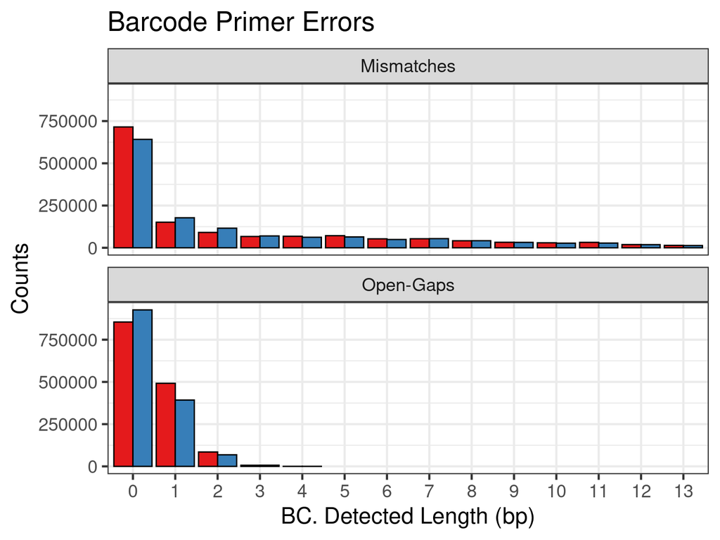

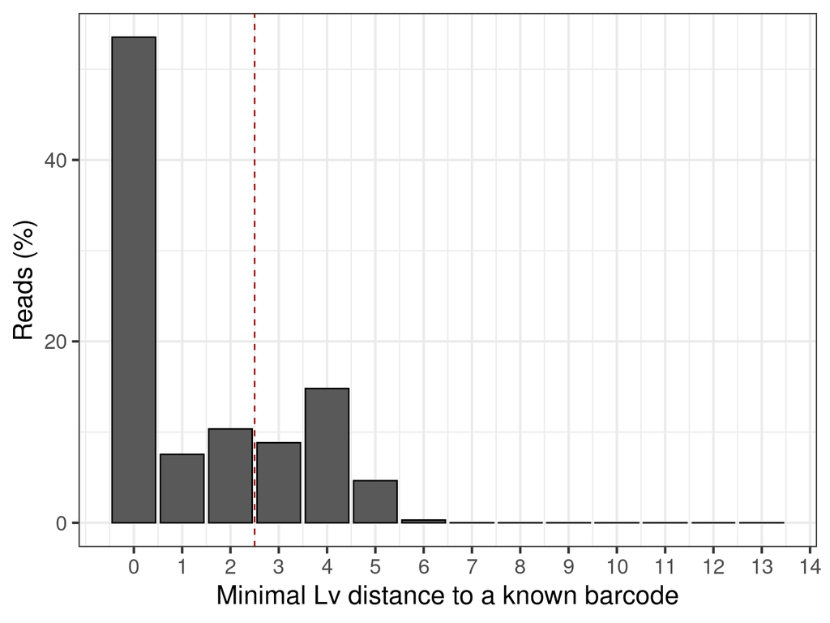

# Optional UMI

UMI are detected and if necessary corrected at the demultiplexing stage.

Deletions are masked with “N” in monomeric UMI.

Trimeric UMI are handled corrected based on a whitelist. Uncertain trimer are masked with “NNN”. Please refer to the method section from the article.

# Barcodes - Demultiplexing

The reads are then demultiplexed using these barcodes.

| Reads with vsearch hit | 1342796.000 |
| --- | --- |
| Reads with correct barcode | 1334269.000 |
| Reads with correct barcode (%, total raw reads) | 42.533 |
| Reads with chimeric barcode pairs | 8527.000 |
| Reads with chimeric barcode pairs (%, total raw reads) | 0.272 |

The barcode sequences are extracted from the reads and compared to the whitelist. To account for RT, PCR and sequencing errors, up-to two mismatches are allowed by default (levenstein distance).

The reads are expected to have the same barcode at both ends. However, in some reads, the barcode is only found at one end or there is a difference :

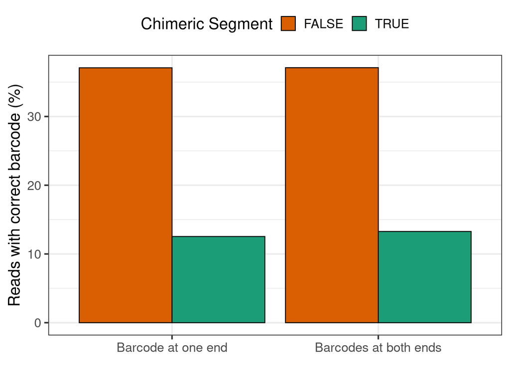

Barcode corrections:

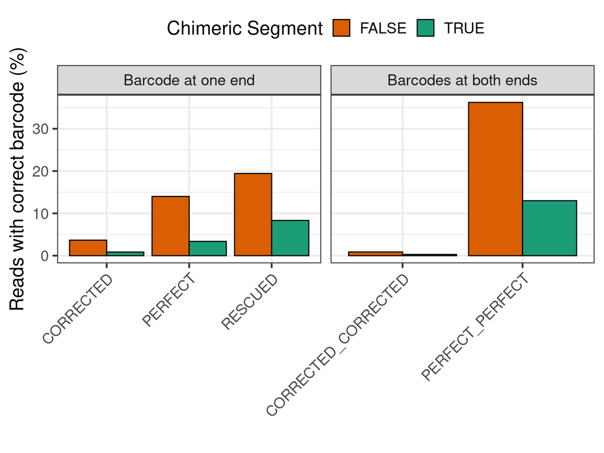

Barcode distribution.

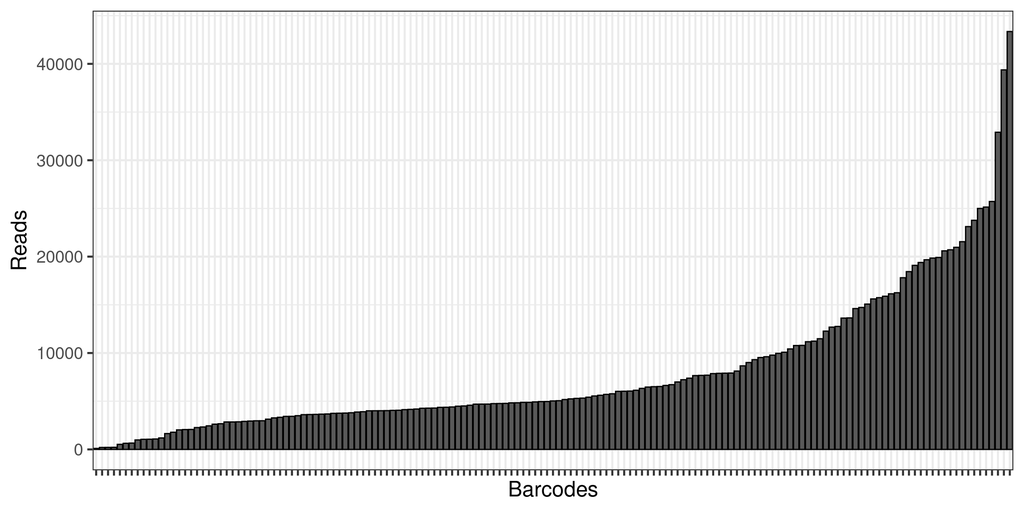